# Python & R in Quarto

Author

Stats 20

Published

May 26, 2026

## Introduction

This document demonstrates how to pass data from Python to R within a single Quarto document.

Our example employs Python for data manipulation and modeling, then passes the predictions off to R for high-quality visualization. Quarto was selected for its flexibility and portability.

## Setup

Two R libraries are needed for this example. The package **reticulate** https://github.com/rstudio/reticulate calls Python in multiple ways from R, allows interchange of objects (e.g., data frames) and can utilize variants of Python.

### Initialize the Python interface in R

```r
library(reticulate)
library(ggplot2)
```

### Import necessary Python libraries

```python
import numpy as np
import pandas as pd
from sklearn.preprocessing import StandardScaler
import torch
import torch.nn as nn
import matplotlib.pyplot as plt
import seaborn as sns
```

## Python Example

We generate some synthetic data, transform it using scikit-learn, perform training with Pytorch, generate predictions from the model to be exported to R.

```python
# 1. Generate Synthetic Data
np.random.seed(42)
X_raw = np.random.uniform(1, 10, (100, 1))
# True relation: y = 2.5 * X + noise with a bit of non-linear wobble
y_raw = 2.5 * X_raw + np.sin(X_raw) * 2 + np.random.normal(0, 1.5, (100, 1))

# 2. Preprocessing with scikit-learn
scaler = StandardScaler()
X_scaled = scaler.fit_transform(X_raw)

# 3. Model Training via PyTorch
# Convert to Tensors
X_tensor = torch.tensor(X_scaled, dtype=torch.float32)
y_tensor = torch.tensor(y_raw, dtype=torch.float32)

# Simple Linear Layer: y = w*x + b
model = nn.Linear(1, 1)
criterion = nn.MSELoss()
optimizer = torch.optim.SGD(model.parameters(), lr=0.1)

# Quick training loop
for epoch in range(200):
    optimizer.zero_grad()
    outputs = model(X_tensor)
    loss = criterion(outputs, y_tensor)
    loss.backward()
    optimizer.step()

# 4. Generate Predictions for Export
with torch.no_grad():
    predictions = model(X_tensor).numpy()

# Combine everything into a Pandas DataFrame
df_results = pd.DataFrame({
    'X_value': X_raw.flatten(),
    'Observed': y_raw.flatten(),
    'Predicted': predictions.flatten()
})

print(df_results.head())
```

```
    X_value   Observed  Predicted
0  4.370861   9.173235  11.456820
1  9.556429  23.180019  23.816818
2  7.587945  21.037146  19.124863
3  6.387926  13.197562  16.264572
4  2.404168   7.025680   6.769132
```

## Using R to access Python objects

The **py** object allows us to interact with Python directly from R. Python objects accessed through the py object are automatically converted into R objects, and can be used with any other R function.

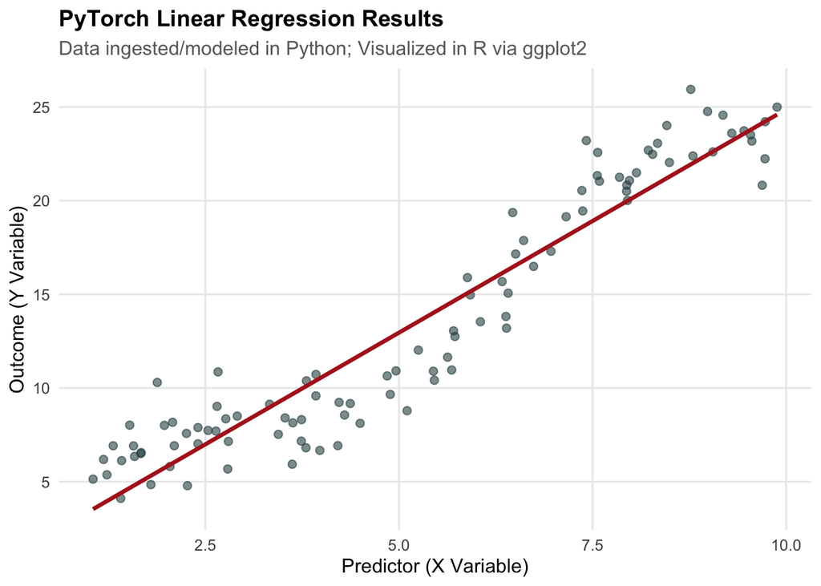

```r
# Get the data from Python
ml_data <- py$df_results

# Use ggplot
ggplot(ml_data, aes(x = X_value)) +
  geom_point(aes(y = Observed), alpha = 0.6, color = "darkslate gray", size = 2) +
  geom_line(aes(y = Predicted), color = "firebrick", linewidth = 1.2) +
  labs(
    title = "PyTorch Linear Regression Results",
    subtitle = "Data ingested/modeled in Python; Visualized in R via ggplot2",
    x = "Predictor (X Variable)",
    y = "Outcome (Y Variable)"
  ) +
  theme_minimal(base_size = 12) +
  theme(
    plot.title = element_text(face = "bold", size = 14),
    plot.subtitle = element_text(color = "dimgray"),
    panel.grid.minor = element_blank()
  )
```

That’s it. The choice of R or Python depends on your resources and your work environment. In large business environments, Python makes more sense. If you are financiang your own education and are limited to a laptop for computing, R is better suited for an academic environment.

## The same plot in Python

A point of contrast between R and Python can be seen in ggplot vs. matplotlib

Matplotlib is powerful but its “imperative” style (telling the computer step-by-step how to draw lines and elements of the plotting canvas) is quite counter to ggplot2’s “declarative” Grammar of Graphics (telling the computer what visual properties map to which data variables).

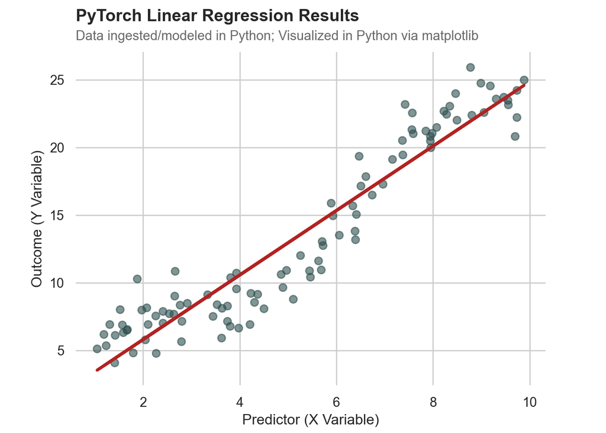

```python
# import matplotlib.pyplot as plt
# import seaborn as sns

# Set a clean base style similar to theme_minimal in ggplot
sns.set_theme(style="whitegrid")

# Initialize the figure and axis objects
fig, ax = plt.subplots(figsize=(7, 5))

# 1. Plot the observed points (mapping color, alpha, size)
ax.scatter(
    df_results['X_value'],
    df_results['Observed'],
    color='darkslategray',
    alpha=0.6,
    s=40,                  # 's' is marker size in points^2
    label='Observed'
)

# 2. Plot the predicted line
ax.plot(
    df_results['X_value'],
    df_results['Predicted'],
    color='firebrick',
    linewidth=2.4,         # Matplotlib line width is doubled compared to ggplot
    label='Predicted'
)

# 3. Titles and Labels (Main title + Subtitle pattern)
# Matplotlib requires manual positioning or using the suptitle/title combo for subtitles
fig.suptitle("PyTorch Linear Regression Results", fontsize=14, fontweight='bold', x=0.125, ha='left')
ax.set_title("Data ingested/modeled in Python; Visualized in Python via matplotlib", color='dimgray', fontsize=11, loc='left', pad=10)

ax.set_xlabel("Predictor (X Variable)")
ax.set_ylabel("Outcome (Y Variable)")

# 4. Final layout tweaks to match the clean 'ggplot' look
ax.grid(visible=True, which='minor', axis='both', linestyle='') # Turn off minor grids
sns.despine(left=True, bottom=True) # Remove the outer border box

plt.show()
```

Python can do anything, like it can impersonate ggplot.

## Compare and Contrast

### Object-Oriented programming vs. a layer on a canvas

- In matplotlib, one must manage both fig (the window) and ax (the specific plot inside the window), in addition calling methods on ax (for example ax.grid, ax.set_xlabel). ggplot2/R handles all of that complex programming so the user doesn’t have to think about it. You start with ggplot(data) and literally add layers (+ geom_point() + geom_line()) onto a single canvas. ggplot frees you to think about the content at the cost of having the power to interact with the tiniest of elements in a visualization.
- In R, you pass the dataframe once at the start of ggplot(), and then simply reference variable names inside the aesthetic mapping aes(). In matplotlib, you must extract columns manually (df_results[‘X_value’], df_results[‘Observed’]) for every single layer you draw. If the dataframe name changes in Python, you have to rewrite many lines of code. In R, you just change the dataframe name.
- ggplot2 understands modern graphic design hierarchies (Title, Subtitle, Caption, Tag) inside a single labs() function. Doing the same in matplotlib requires using a combination of fig.suptitle() and ax.set_title(), manually turning off bounding boxes, and aligning text anchors (ha=‘left’) to prevent overlapping. Again, there is a power trade-off here. You have complete control with MatPlotLib to create a masterpiece. You do not have that level of control in ggplot. The question is one of need.

## Complicate the graphic with faceting

- Recall faceting is simply accounting for subgroups. ggplot is well designed here.
- In matplotlib, creating a grid of subplots requires calculating the grid dimensions ahead of time, managing a multi-dimensional array of axes (axs[0, 0], axs[0, 1]), and running explicit loops over your data groups to manually assign data to specific boxes.
- In ggplot2, you simply add one line: + facet_wrap(~ group). R handles the splitting, the canvas layout, and the structural spacing. You can adjust to some extent.

```python
# import numpy as np
# import pandas as pd

np.random.seed(101)
n_samples = 40
cohorts = ['Cohort A (Traditional)', 'Cohort B (Non-Traditional)', 'Cohort C (Accelerated)']

df_list = []
for c in cohorts:
    X = np.random.uniform(1, 10, n_samples)
    # Give each cohort a completely different slope/intercept/noise profile
    if 'A' in c:
        y = 1.8 * X + np.random.normal(0, 1.0, n_samples)
        y_pred = 1.7 * X + 0.2
    elif 'B' in c:
        y = 0.5 * X + 5.0 + np.random.normal(0, 1.5, n_samples)
        y_pred = 0.6 * X + 4.5
    else: # Cohort C
        y = 3.2 * X - 4.0 + np.random.normal(0, 0.8, n_samples)
        y_pred = 3.1 * X - 3.5

    df_list.append(pd.DataFrame({'X_val': X, 'Observed': y, 'Predicted': y_pred, 'Group': c}))

df_multi = pd.concat(df_list, ignore_index=True)
```

## ggplot and facet_wrap

[figure not shown]

```r
ggplot(py$df_multi, aes(x = X_val)) +
  geom_point(aes(y = Observed), alpha = 0.6, color = "darkslate gray") +
  geom_line(aes(y = Predicted), color = "firebrick", linewidth = 1) +
  facet_wrap(~ Group) +  # this is all we need to do
  labs(
    title = "Model Performance Across Student Cohorts",
    subtitle = "One extra line of code splits the visualization cleanly by category",
    x = "Study Hours per Week",
    y = "Assessment Score"
  ) +
  theme_minimal(base_size = 12) +
  theme(
    plot.title = element_text(face = "bold"),
    strip.text = element_text(face = "bold", color = "darkred"), # Styles the facet headers
    panel.spacing = unit(1.5, "lines") # Adds breathing room between plots
  )
```

## Pythonic plotting of the same

[figure not shown]

```python
# import matplotlib.pyplot as plt
# import seaborn as sns

sns.set_theme(style="whitegrid")
unique_groups = df_multi['Group'].unique()

# 1. Define the grid architecture up front (1 row, 3 columns)
# Sharey=True ensures the Y-axes match, mimicking ggplot's default behavior
fig, axs = plt.subplots(1, 3, figsize=(11, 4), sharey=True, sharex=True)

# 2. Iterate through the grid axes and data groups simultaneously
for i, group_name in enumerate(unique_groups):
    # Filter dataset for the current sub-population
    sub_data = df_multi[df_multi['Group'] == group_name]
    ax = axs[i] # Target the specific subplot axis

    # Draw layers explicitly on the targeted axis
    ax.scatter(sub_data['X_val'], sub_data['Observed'], color='darkslategray', alpha=0.6, s=30)
    ax.plot(sub_data['X_val'], sub_data['Predicted'], color='firebrick', linewidth=2)

    # Set individual subplot titles
    ax.set_title(group_name, fontsize=11, fontweight='bold', color='darkred')

    # Manage x-axis labels across the grid safely
    ax.set_xlabel("Study Hours per Week")

# 3. Handle global labels (since setting ylabel on all axes duplicates text)
axs[0].set_ylabel("Assessment Score")

# 4. Global Titles and Layout spacing adjustments
fig.suptitle("Model Performance Across Student Cohorts", fontsize=14, fontweight='bold', x=0.08, ha='left')
fig.text(0.08, 0.92, "Requires manual loops and subplots array mapping to split by category", color='dimgray', fontsize=10)

plt.tight_layout() # Essential to prevent axis labels from clipping overlapping panels
sns.despine(left=True, bottom=True)
plt.show()
```

## Faceting Comments

- In Python, if you suddenly decide to add a fourth or fifth group to the data, the code breaks immediately because subplots(1, 3)above creates an array of exactly 3 axes. One must re-calculate the row/column math (subplots(2, 2) or subplots(2, 3)), map out 2D indexing (axs[r, c]), and adjust the loop logic.
- In R, facet_wrap() doesn’t care if there are 3 groups or 12 groups. R wraps the boxes into columns dynamically.
- In matplotlib, every subplot panel acts in isolation. If you want to add a reference line or label, you must bundle that configuration inside a for loop.
- ggplot2 treats the data globally. ggplot evaluates the mappings globally and splits the space up structurally without making the you coordinate the mechanics of the array.